# **Predicting 2026 FIFA WorldCup Winner**

Tutorial by Bingyu Cai and Luis Aguayo

# **Why build a FIFA World Cup predictor?**

Football (or soccer) is undoubtedly one of the most popular sport in the world. The FIFA World Cup is the most influential event in global sports and each World Cup serves not only as the highest stage for international football competition but also as a worldwide festival that engages billions of spectators. Its impact extends far beyond the sport itself, influencing numerous industries such as entertainment, sports media, gambling markets, food and beverage, hospitality, transportation, and tourism. The event generates immense economic and social effects across the globe.

The identity of the World Cup champion, in particular, becomes a focal point of worldwide attention. Winning the title brings substantial commercial value: increased sponsorship opportunities, rising market value of players, and enhanced national brand image.

Therefore, predicting the World Cup outcome is more than satisfying public curiosity—it represents an important topic that combines commercial interest and global attention.

# **Data Collection**

Fortunately, a variety of publicly available datasets related to World Cup prediction can be found online. To predict the World Cup champion, historical match records are essential. Therefore, we collected a comprehensive dataset of international football match results from [Kaggle](https://www.kaggle.com/). In addition, a team’s overall strength is closely related to its FIFA ranking and points. We obtained historical FIFA ranking and point data from [GitHub](https://github.com/) and incorporated them as key features in our model.

We downloaded data from Kaggle and Github and obtained these files:

- [former_names.csv](https://www.kaggle.com/datasets/martj42/international-football-results-from-1872-to-2017/data): This file contains the former names and corresponding current names of 34 countries, which is used to standardize country names across different datasets.
- [results.csv](https://www.kaggle.com/datasets/martj42/international-football-results-from-1872-to-2017/data): This dataset includes 48,673 results of international football matches starting from the very first official match in 1872 up to 2025. The matches range from FIFA World Cup to FIFI Wild Cup to regular friendly matches.
- [ranking_fifa_historical.csv](https://github.com/Dato-Futbol/fifa-ranking): This file contains FIFA rankings and points for national teams from December 31, 1992 to September 19, 2024.
- A-L.xlsx: This file was manually created by us based on the official World Cup groupings. There are still six teams whose qualification status has not been finalized. Since the playoffs for the 6 remaining teams are in March, 2026, in order to proceed with our simulation and prediction, we selected Italy, Poland, Denmark, Turkey, Bolivia, and Jamaica as assumed qualifiers. This selection was based on their current FIFA rankings and points, choosing the six strongest teams with the highest likelihood of qualification among those not yet confirmed.

The main tool used for this project was python and relevant libraries/modules for our collection/analysis/prediction. We also used Google Colab to develop this project.

To begin with we start off by importing the necessary libraries/modules and use the pandas library to bring the data and store it in dataframes

```python
# Import necessary libraries
import pandas as pd
import numpy as np
import matplotlib.pyplot as plt
import seaborn as sns
from itertools import product, combinations
from collections import Counter
import sklearn
from sklearn import linear_model
from sklearn.linear_model import LogisticRegression
from xgboost import XGBClassifier
from sklearn import ensemble
from sklearn.ensemble import RandomForestClassifier
import xgboost as xgb
from sklearn.model_selection import train_test_split
from sklearn.metrics import confusion_matrix, roc_curve, roc_auc_score
from sklearn.pipeline import Pipeline
from sklearn.preprocessing import PolynomialFeatures
from sklearn.metrics import accuracy_score, recall_score, precision_score, f1_score
from scipy.stats import pearsonr, spearmanr
import warnings
```

```python
# Use pandas to read chosen datasets into dataframes and print the shape of each dataframe
df = pd.read_csv("results.csv")
former_names = pd.read_csv("former_names.csv")
fifa = pd.read_csv("ranking_fifa_historical.csv") # How did we get this again?
matches = pd.read_excel("A-L.xlsx") # How did we get this again?
print("matches:",df.shape)
print("results:", df.shape)
print("former_names:", former_names.shape)
print("fifa:", fifa.shape)
```

```
matches: (48673, 9)
results: (48673, 9)
former_names: (34, 4)
fifa: (67894, 6)
```

```python
# print the first few rows of results
df.head()
```

|  | date | home_team | away_team | home_score | away_score | tournament | city | country | neutral |
| --- | --- | --- | --- | --- | --- | --- | --- | --- | --- |
| 0 | 1872-11-30 | Scotland | England | 0 | 0 | Friendly | Glasgow | Scotland | False |
| 1 | 1873-03-08 | England | Scotland | 4 | 2 | Friendly | London | England | False |
| 2 | 1874-03-07 | Scotland | England | 2 | 1 | Friendly | Glasgow | Scotland | False |
| 3 | 1875-03-06 | England | Scotland | 2 | 2 | Friendly | London | England | False |
| 4 | 1876-03-04 | Scotland | England | 3 | 0 | Friendly | Glasgow | Scotland | False |

The results data consist of samples with the following features:

- date - date of the match
- home_team - the name of the home team
- away_team - the name of the away team
- home_score - full-time home team score including extra time, not including penalty-shootouts
- away_score - full-time away team score including extra time, not including penalty-shootouts
- tournament - the name of the tournament
- city - the name of the city/town/administrative unit where the match was played
- country - the name of the country where the match was played
- neutral - TRUE/FALSE column indicating whether the match was played at a neutral venue

```python
# print the first few rows of fifa ranking
fifa.head(2)
```

|  | team | total_points | date | id | id_num | team_short |
| --- | --- | --- | --- | --- | --- | --- |
| 0 | Argentina | 1855.20 | 2024-02-15 | id14289 | 14289 | ARG |
| 1 | France | 1845.44 | 2024-02-15 | id14289 | 14289 | FRA |

The fifa_ranking_historical data consists of samples with the following features:

- team: the full name of the national team
- total_points: the official FIFA points assigned to the team, it's current total fifa points
- date: the release date of the FIFA ranking
- id: a unique identifier for each national team
- id_num: a numerical version of the team identifier
- team_short: the abbreviated name of the national team

# **Data preprocessing and cleaning**

Because some match records are very old, certain countries have changed names over time, and different datasets use inconsistent naming formats. To ensure accurate data matching and analysis, we standardized all country names by mapping old names to modern ones and unifying the formatting. We decided to remove any observations before 1992 since national football teams did no have FIFA ranking at the time. (source: https://www.sportmonks.com/football-api/fifa-rankings/)

FIFA rankings are calculated each official match and follow a formula, if you want to learn more about how these rankings get calculated click [here](https://www.transfermarkt.us/statistik/weltrangliste).

```python
# Replace the former country name with current country name in results
name_map = dict(zip(former_names['former'], former_names['current']))
df['home_team'] = df['home_team'].replace(name_map)
df['away_team'] = df['away_team'].replace(name_map)

# During post-processing, we found inconsistencies in several country names, now standardizing them.
ranking_mapping = {
    'USA': 'United States',
    'Korea Republic': 'South Korea',
    'IR Iran': 'Iran',
    "Côte d'Ivoire": 'Ivory Coast'}
df_mapping = {'Cape Verde': 'Cabo Verde'}

fifa['team'] = fifa['team'].replace(ranking_mapping)
df['home_team'] = df['home_team'].replace(df_mapping)
df['away_team'] = df['away_team'].replace(df_mapping)
```

```python
# Unify data format
df['date'] = pd.to_datetime(df['date'], errors='coerce',)
print(df['date'].isna().sum())
fifa['date'] = pd.to_datetime(fifa['date'], errors='coerce')
print(fifa['date'].isna().sum())
```

```
0
0
```

```python
# Remove matches before 1992,
# teams in these matches didn't have fifa ranking at that time
df = df[df['date'] >= pd.to_datetime('1992-01-01')]
```

```python
df.head()
```

|  | date | home_team | away_team | home_score | away_score | tournament | city | country | neutral |
| --- | --- | --- | --- | --- | --- | --- | --- | --- | --- |
| 18103 | 1992-01-04 | Egypt | Czechoslovakia | 2 | 0 | Friendly | Cairo | Egypt | False |
| 18104 | 1992-01-05 | DR Congo | Ivory Coast | 2 | 0 | Friendly | Kinshasa | Zaïre | False |
| 18105 | 1992-01-05 | Guyana | Barbados | 0 | 2 | Friendly | Georgetown | Guyana | False |
| 18106 | 1992-01-07 | Egypt | Norway | 0 | 0 | Friendly | Cairo | Egypt | False |
| 18107 | 1992-01-12 | Cameroon | Morocco | 1 | 0 | African Cup of Nations | Dakar | Senegal | True |

We now aim to add the corresponding FIFA rankings and points to both teams for each match

```python
# Assign FIFA ranking to the team based on the match date and ranking teams based on the FIFA points
fifa = fifa[['team', 'total_points', 'date']].dropna(subset=['team', 'date'])
fifa = fifa.sort_values(['team', 'date']).drop_duplicates(['team', 'date'], keep='last')
fifa['rank'] = fifa.groupby('date')['total_points'].rank(ascending=False, method='dense').astype('Int64')
```

```python
# Define the "closest date matching" function
# For each match, we matched the temporally closest FIFA ranking and point data for each team
# by aligning the ranking date to the most recent FIFA ranking released prior to the match date.
def nearest_asof_team(df_key, team_col, prefix):
    out = []
    for team, sub in df_key.groupby(team_col):
        left = sub.sort_values('date').copy()
        right = fifa[fifa['team'] == team][['date', 'total_points', 'rank']].sort_values('date')
        if right.empty:
            left[f'{prefix}_fifa_points'] = pd.NA
            left[f'{prefix}_rank'] = pd.NA
        else:
            merged = pd.merge_asof(left, right, on='date', direction='nearest')
            left[f'{prefix}_fifa_points'] = merged['total_points'].values
            left[f'{prefix}_rank'] = merged['rank'].values
        out.append(left[['date', team_col, f'{prefix}_fifa_points', f'{prefix}_rank']])
    return pd.concat(out, ignore_index=True)
warnings.filterwarnings("ignore")
```

```python
#Add the most recent FIFA ranking and points to each match for both the home and away teams
home = nearest_asof_team(df[['date','home_team']], 'home_team', 'home')
away = nearest_asof_team(df[['date','away_team']], 'away_team', 'away')
df = df.merge(home, on=['date', 'home_team'], how='left')
df = df.merge(away, on=['date', 'away_team'], how='left')
df = df.dropna()
df.head(3)
df.columns
```

```
Index(['date', 'home_team', 'away_team', 'home_score', 'away_score',
       'tournament', 'city', 'country', 'neutral', 'home_fifa_points',
       'home_rank', 'away_fifa_points', 'away_rank'],
      dtype='object')
```

Like we mentioned earlier, there are still six remaining countries whose qualification has not been determined. Therefore we made reasonable assumptions for these six teams in our model. They are Denmark, Turkey, Poland, Italy, Bolivia and Jamaica. These assumptions were based on their FIFA rankings.

```python
# Extract data from 48 countries participating in the World Cup
teams_2026 = [
    # Europe (16)
    'France','England','Germany','Spain','Portugal','Netherlands','Italy','Croatia','Belgium',
    'Denmark','Switzerland','Poland','Austria','Norway','Turkey','Scotland',
    # South America (7)
    'Brazil','Argentina','Uruguay','Colombia','Ecuador','Bolivia','Paraguay',
    # North/Central America (7)
    'United States','Mexico','Canada','Haiti','Panama','Jamaica','Curaçao',
    # Africa (9)
    'Morocco','Senegal','Cabo Verde','Egypt','Algeria','Tunisia','Ghana','South Africa','Ivory Coast',
    # Asia (8)
    'Japan','South Korea','Iran','Saudi Arabia','Australia','Qatar','Uzbekistan','Jordan',
    # Oceania (1)
    'New Zealand'
]
df_2026 = df[(df['home_team'].isin(teams_2026)) | (df['away_team'].isin(teams_2026))].copy()
len(df_2026)
```

```
14400
```

The dataset contains various types of matches, some of which are not meaningful to our prediction task. Therefore, we filtered out these matches and kept only the competitions that provide real analytical value.

```python
# current tournament types
tournament_counts = df_2026['tournament'].value_counts()
print(len(tournament_counts))
print(tournament_counts)
```

```
72
tournament
Friendly                                5409
FIFA World Cup qualification            3622
UEFA Euro qualification                 1020
African Cup of Nations qualification     590
FIFA World Cup                           476
                                        ...
Four Nations' Cup                          2
Copa Lipton                                1
SKN Football Festival                      1
Copa Confraternidad                        1
Navruz Cup                                 1
Name: count, Length: 72, dtype: int64
```

```python
# Select valuable matches based on tournament types
keep_keywords = ['world cup', 'euro', 'copa', 'african', 'asian', 'gold cup',
                 'nations league', 'qualif', 'championship', 'arab cup',
                 'gulf cup', 'aff', 'cosa', 'ceca', 'waff', 'uncaf', 'friendly']

df_2026 = df_2026[df_2026['tournament'].str.lower().apply(lambda x: any(k in x for k in keep_keywords))]
```

```python
print(len(df_2026))
print(df_2026['tournament'].value_counts())
len(df_2026['tournament'].unique())
```

```
13751
tournament
Friendly                                 5409
FIFA World Cup qualification             3622
UEFA Euro qualification                  1020
African Cup of Nations qualification      590
FIFA World Cup                            476
African Cup of Nations                    375
Copa América                              335
Gold Cup                                  297
UEFA Euro                                 292
UEFA Nations League                       282
AFC Asian Cup                             217
AFC Asian Cup qualification               178
Gulf Cup                                  127
CONCACAF Nations League                   100
COSAFA Cup                                 69
CFU Caribbean Cup qualification            62
WAFF Championship                          62
Asian Games                                53
Arab Cup                                   53
UNCAF Cup                                  44
EAFF Championship                          39
Gold Cup qualification                     16
CONCACAF Nations League qualification       8
Copa Paz del Chaco                          7
East Asian Games                            4
Nordic Championship                         4
Copa América qualification                  3
Arab Cup qualification                      3
COSAFA Cup qualification                    2
Copa Lipton                                 1
Copa Confraternidad                         1
Name: count, dtype: int64
```

```
31
```

```python
# Add match result column
def label_result(row):
    if row['home_score'] > row['away_score']:
        return 'Home Win'
    elif row['home_score'] < row['away_score']:
        return 'Away Win'
    else:
        return 'Draw'
```

```python
df_2026['match_result'] = df.apply(label_result, axis=1)
df_2026.head(3)
```

|  | date | home_team | away_team | home_score | away_score | tournament | city | country | neutral | home_fifa_points | home_rank | away_fifa_points | away_rank | match_result |
| --- | --- | --- | --- | --- | --- | --- | --- | --- | --- | --- | --- | --- | --- | --- |
| 0 | 1992-01-04 | Egypt | Czechoslovakia | 2 | 0 | Friendly | Cairo | Egypt | False | 45.0 | 12 | 47.0 | 10 | Home Win |
| 3 | 1992-01-07 | Egypt | Norway | 0 | 0 | Friendly | Cairo | Egypt | False | 45.0 | 12 | 49.0 | 8 | Draw |
| 4 | 1992-01-12 | Cameroon | Morocco | 1 | 0 | African Cup of Nations | Dakar | Senegal | True | 43.0 | 13 | 32.0 | 21 | Home Win |

```python
# reset matches columns and set "team" as index
matches.columns = matches.iloc[0]
matches = matches[1:]
matches.set_index('team',inplace=True)
matches.head(4)
```

| team | groups | First match against | Second match against | Third match against |
| --- | --- | --- | --- | --- |
| Mexico | A | South Korea | South Africa | Denmark |
| South Korea | A | Mexico | Denmark | South Korea |
| South Africa | A | Denmark | Mexico | South Korea |
| Denmark | A | South Africa | Korea Republic | Mexico |

# **Exploratory data analysis & Data visualization**

This section of the data life cycle is dedication to exploratory data analysis, where our goal is move beyond the raw data and gain a depper understanding of the patterns, strucutures and relationships through the use of graphs and statistical analysis.

Statistical Analysis #1: Is there a relationship between higher FIFA ranking and match outcome?

```python
# Rank difference (home_rank - away_rank)
df_2026['rank_diff'] = df_2026['home_rank'] - df_2026['away_rank']

# Goal diff  (home_score - away_score)
df_2026['goal_diff'] = df_2026['home_score'] - df_2026['away_score']

# Drop rows with missing rank data
df_clean = df_2026.dropna(subset=['rank_diff', 'goal_diff'])

# Calculate correlation (both Pearson and Spearman for robustness)
pearson_corr, pearson_p = pearsonr(df_clean['rank_diff'], df_clean['goal_diff'])
spearman_corr, spearman_p = spearmanr(df_clean['rank_diff'], df_clean['goal_diff'])

print("Pearson correlation:", round(pearson_corr, 3), " (p =", round(pearson_p, 4), ")")
print("Spearman correlation:", round(spearman_corr, 3), " (p =", round(spearman_p, 4), ")")
```

```
Pearson correlation: -0.579  (p = 0.0 )
Spearman correlation: -0.563  (p = 0.0 )
```

Rank Difference (home_rank - away_rank):

- Negative → the home team is better ranked (lower number).
- Positive → the away team is better ranked.

Goal Difference (home_score - away_score):

- Positive → the home team scored more (home win).
- Negative → the away team scored more (away win).

Conclusion - Given that both correlations are similar and are strong and negative, we can be confident saying that as the home team ranking decreases, the goal difference tends to decrease and vice-versa, thus lower ranked team are more likely to lose by larger margin or goal difference.

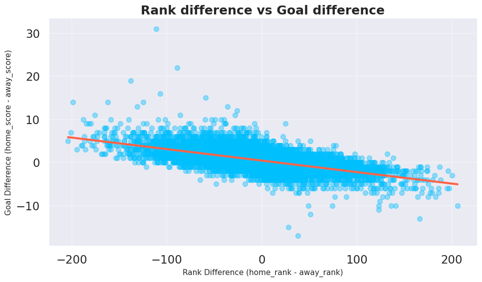

```python
# Visualization
sns.set_theme(style="darkgrid", context="talk")

plt.figure(figsize=(10,6))

sns.regplot(
    x='rank_diff', y='goal_diff', data=df_clean,
    scatter_kws={'alpha':0.4, 'color':'#00BFFF', 's':50},
    line_kws={'color':'#FF6347', 'lw':3}
)

plt.title("Rank difference vs Goal difference", fontsize=18, fontweight='bold')
plt.xlabel("Rank Difference (home_rank - away_rank)", fontsize=11)
plt.ylabel("Goal Difference (home_score - away_score)", fontsize=11)

plt.grid(alpha=0.3)
sns.despine()
plt.tight_layout()
plt.show()
```

Our visualization of our regression supports our statistical finding as we can see that our scatter plot shows a clear downward trend, as rank_diff increases, goal_diff decreases.

Statistical Analysis #2: EDA - What teams have won the most matches in the FIFA world cup since 1992?

```python
wc_df = df_2026[df_2026['tournament'].str.fullmatch("FIFA World Cup", case=False, na=False)].copy()


wc_df['winner'] = np.where(wc_df['home_score'] > wc_df['away_score'],
                           wc_df['home_team'],
                           np.where(wc_df['away_score'] > wc_df['home_score'],
                                    wc_df['away_team'],
                                    'Draw'))

win_counts = wc_df[wc_df['winner'] != 'Draw']['winner'].value_counts().reset_index()
win_counts.columns = ['Team', 'Wins']
top10_winners = win_counts.head(10)
```

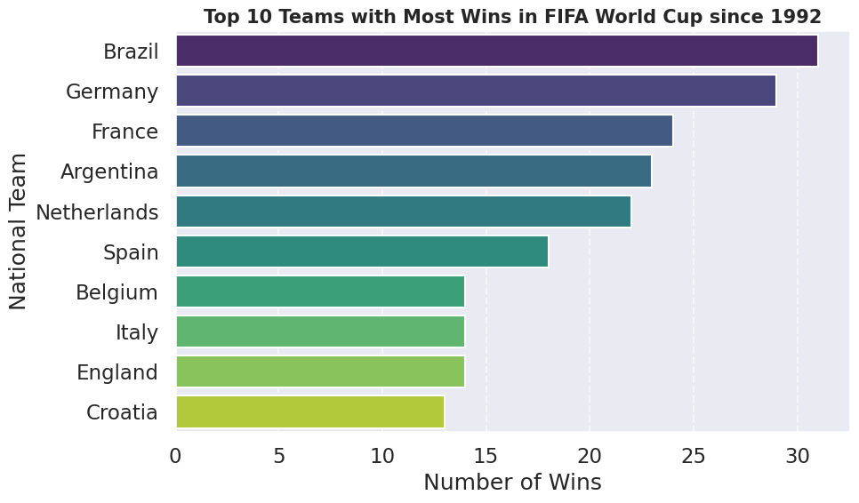

```python
# Visualization
plt.figure(figsize=(10,6))
sns.barplot(data=top10_winners, x='Wins', y='Team', palette='viridis', legend=True)

plt.title('Top 10 Teams with Most Wins in FIFA World Cup since 1992', fontsize=15, weight='bold')
plt.xlabel('Number of Wins')
plt.ylabel('National Team')
plt.grid(axis='x', linestyle='--', alpha=0.6)
plt.tight_layout()
plt.show()
```

Statistical Analysis #3: Hypothesis testing - Comparing average goals scored between South American teams and European teams in FIFA World Cup tournaments

Null hypothesis (H₀): The average goals scored per FIFA World Cup match by European and South American teams are the same.

Alternative hypothesis (H₁): The Average goals are different.

α = 0.05

chosen test statistic: t-test

```python
# Filtering FIFA World Cup matches since 1992 (Our sample)
wc_cont_df = df_2026[df_2026['tournament'] == 'FIFA World Cup'].copy()
```

```python
#Mapping national teams with their respective continent
continent_map = {
    # Europe
    'France': 'Europe', 'England': 'Europe', 'Germany': 'Europe', 'Spain': 'Europe',
    'Portugal': 'Europe', 'Netherlands': 'Europe', 'Italy': 'Europe', 'Croatia': 'Europe',
    'Belgium': 'Europe', 'Denmark': 'Europe', 'Switzerland': 'Europe', 'Poland': 'Europe',
    'Austria': 'Europe', 'Norway': 'Europe', 'Scotland': 'Europe', 'Turkey': 'Europe',

    # South America
    'Brazil': 'South America', 'Argentina': 'South America', 'Uruguay': 'South America',
    'Colombia': 'South America', 'Ecuador': 'South America', 'Paraguay': 'South America', 'Bolivia': 'South America',

    # North/Central America
    'United States': 'North America', 'Mexico': 'North America', 'Canada': 'North America',
    'Haiti': 'North America', 'Panama': 'North America', 'Jamaica': 'North America',

    # Africa
    'Morocco': 'Africa', 'Senegal': 'Africa', 'Cabo Verde': 'Africa', 'Egypt': 'Africa',
    'Algeria': 'Africa', 'Tunisia': 'Africa', 'Ghana': 'Africa', 'South Africa': 'Africa', 'Ivory Coast': 'Africa',

    # Asia
    'Japan': 'Asia', 'South Korea': 'Asia', 'Iran': 'Asia', 'Saudi Arabia': 'Asia',
    'Australia': 'Asia', 'Qatar': 'Asia', 'Uzbekistan': 'Asia', 'Iraq': 'Jordan',

    # Oceania
    'New Zealand': 'Oceania'
}

wc_cont_df['home_continent'] = wc_df['home_team'].map(continent_map)
wc_cont_df['away_continent'] = wc_df['away_team'].map(continent_map)
```

```python
# Home goals
home_goals = wc_cont_df[['home_team', 'home_score', 'home_continent']].rename(
    columns={'home_team': 'team', 'home_score': 'goals', 'home_continent': 'continent'}
)
# Away goals
away_goals = wc_cont_df[['away_team', 'away_score', 'away_continent']].rename(
    columns={'away_team': 'team', 'away_score': 'goals', 'away_continent': 'continent'}
)
# Combine
all_goals = pd.concat([home_goals, away_goals])

europe_goals = all_goals.loc[all_goals['continent'] == 'Europe', 'goals']
south_america_goals = all_goals.loc[all_goals['continent'] == 'South America', 'goals']
```

```python
from scipy.stats import ttest_ind

# Run t-test
t_stat, p_val = ttest_ind(europe_goals, south_america_goals, equal_var=False)
print(f"T-statistic: {t_stat:.3f}, P-value: {p_val:.3f}")
```

```
T-statistic: -0.101, P-value: 0.919
```

Conclusion:

- Since P-value=0.919 > 0.05 we fail to reject the null hypothesis, therefore there is no statistically significant difference in average scored goals between South American and European teams in FIFA World Cup matches.
- The 2 regions/continents perform similarly in terms of goals scored on average.

```python
print(europe_goals.count())
print(south_america_goals.count())
```

```
371
156
```

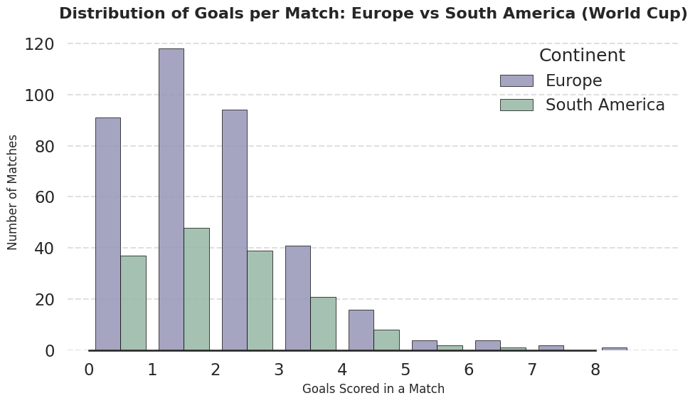

```python
# Visualization

# Combine both groups
plot_df = pd.DataFrame({
    'Goals': list(europe_goals) + list(south_america_goals),
    'Continent': (['Europe'] * len(europe_goals)) + (['South America'] * len(south_america_goals))
})

sns.set_style("white")
custom_palette = {'Europe': '#9596b7', 'South America': '#95b7a5'}
plt.figure(figsize=(10, 6))

# histogram
histplot = sns.histplot(
    data=plot_df,
    x='Goals',
    hue='Continent',
    multiple='dodge',
    shrink=0.8,
    bins=range(0, int(plot_df['Goals'].max()) + 2),
    palette=custom_palette, # Use the explicit palette
    alpha=0.85,
    edgecolor='black',
    linewidth=0.5
)


# Title and axis labels
plt.title("Distribution of Goals per Match: Europe vs South America (World Cup)",
          fontsize=16, fontweight='bold', pad=15)
plt.xlabel("Goals Scored in a Match", fontsize=12, fontweight='medium')
plt.ylabel("Number of Matches", fontsize=12, fontweight='medium')

# Customize X-axis to show integer ticks clearly
max_goals = int(plot_df['Goals'].max())
plt.xticks(range(0, max_goals + 1))

sns.despine(trim=True, left=True)
plt.grid(axis='y', linestyle='--', alpha=0.6)

plt.tight_layout()
plt.show()
```

```python
#calculating the ranking from the most recent match
ranks = []
for x in teams_2026:
    rank_df = df[(df['home_team']==x) | (df['away_team']==x)].sort_values(['date','home_rank'],ascending=False).reset_index(drop=True)

    if not rank_df.empty:
        first_match = rank_df.iloc[0]
        if first_match['home_team']==x:
            rank = first_match['home_rank']
        else:
            rank = first_match['away_rank']
        ranks.append(rank)
    else:
        ranks.append(None)

team_ranks = pd.DataFrame({'Team':teams_2026,'Rank':ranks})
team_ranks['Rank'] = team_ranks['Rank'].fillna(0).astype(int)
team_ranks = team_ranks[team_ranks['Rank']>0]
team_ranks = team_ranks.sort_values(by='Rank').reset_index(drop=True)
team_ranks.index = team_ranks.index + 1
team_ranks.head()
```

|  | Team | Rank |
| --- | --- | --- |
| 1 | Argentina | 1 |
| 2 | France | 2 |
| 3 | Spain | 3 |
| 4 | England | 4 |
| 5 | Brazil | 5 |

# **Machine Learning**

We aim to apply machine learning techniques to the problem of predicting the 2026 FIFA World Cup champion. Our objective is to estimate match outcomes and ultimately identify the national team with the highest probability of winning the tournament.

We use logistic regression combined with second-degree polynomial features. The model is trained using historical match data. To simulate the full tournament and determine the most likely champion, we employ a Monte Carlo simulation. Using the predicted win probabilities from the logistic regression model, we repeatedly simulate the 2026 World Cup 1,000 times, randomly sampling match outcomes according to their predicted probabilities. After all simulations, we count the number of tournament wins for each team and select the country with the highest number of simulated championships as the predicted World Cup winner.

## Train the model

```python
# We define home_won as the prediction target, indicating whether the home team wins a match.
# The model is trained using rank_diff and fifa_points_diff as input features
df_2026["home_won"] = df_2026["match_result"].apply(lambda x: 1 if x == "Home Win" else 0)
df_2026["fifa_points_diff"] = df_2026["home_fifa_points"] - df_2026["away_fifa_points"]
df_2026["rank_diff"] = df_2026["home_rank"] - df_2026["away_rank"]
```

```python
use_col = ['date','home_team','away_team','home_rank','away_rank','rank_diff',
           'home_fifa_points','away_fifa_points','fifa_points_diff','home_won']
newdf_2026 = df_2026[use_col]
newdf_2026.shape
```

```
(13751, 10)
```

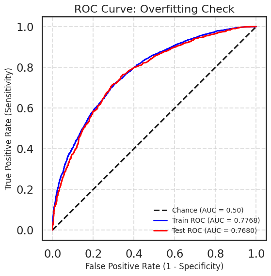

```python
# train the model
X, y = newdf_2026.loc[:,["rank_diff", "fifa_points_diff"]], newdf_2026["home_won"]
X_train, X_test, y_train, y_test = train_test_split(X, y, test_size=0.2, random_state=42)

logreg = linear_model.LogisticRegression(random_state=42)
features = PolynomialFeatures(degree = 2)
model = Pipeline([("polynomial_features", features),("logistic_regression", logreg)])
model = model.fit(X_train, y_train)

# Roc curve
y_proba_test = model.predict_proba(X_test)[:, 1]
fpr_test, tpr_test, _ = roc_curve(y_test, y_proba_test)
auc_test = roc_auc_score(y_test, y_proba_test)


y_proba_train = model.predict_proba(X_train)[:, 1]
fpr_train, tpr_train, _ = roc_curve(y_train, y_proba_train)
auc_train = roc_auc_score(y_train, y_proba_train)

plt.figure(figsize=(6, 6), dpi=100)
ax = plt.gca()
ax.plot([0, 1], [0, 1], 'k--', label='Chance (AUC = 0.50)')

# Plot Training ROC Curve
ax.plot(fpr_train, tpr_train,
        label=f'Train ROC (AUC = {auc_train:.4f})',
        color='blue', linewidth=2)

# Plot Test ROC Curve
ax.plot(fpr_test, tpr_test,
        label=f'Test ROC (AUC = {auc_test:.4f})',
        color='red', linewidth=2)

# Set labels and title
ax.set_title('ROC Curve: Overfitting Check', fontsize=16)
ax.set_xlabel('False Positive Rate (1 - Specificity)', fontsize=12)
ax.set_ylabel('True Positive Rate (Sensitivity)', fontsize=12)

# Add Legend and ensure square aspect ratio
ax.legend(loc="lower right", fontsize=10)
ax.set_aspect('equal', adjustable='box')
ax.grid(True, linestyle='--', alpha=0.6)

plt.show()
```

The ROC curve shows that our model achieves an AUC of 0.7768 on the training data and 0.7680 on the test data. The close proximity between these two values, with the test AUC being only slightly lower than the training AUC, indicates that the model does not overfit. Instead, it demonstrates a good performance to distinguish home wins from non-wins. Furthermore, we can see that our model performs almost identically on training data and on test data, indicating good model generalization.

## Prediction and Monte Carlo simulations

During the prediction stage, we restrict the analysis to matches played after 2020, as results from much earlier periods are considered less representative of current team strength and therefore have limited predictive relevance.

```python
world_cup_rankings_home = newdf_2026[["home_team","home_rank","home_fifa_points"]].loc[newdf_2026["home_team"].isin(teams_2026) & (newdf_2026["date"]>"2020-01-01")]
world_cup_rankings_away = newdf_2026[["away_team","away_rank","away_fifa_points"]].loc[newdf_2026["away_team"].isin(teams_2026) & (newdf_2026["date"]>"2020-01-01")]
world_cup_rankings_home = world_cup_rankings_home.groupby("home_team").mean()
world_cup_rankings_away = world_cup_rankings_away.groupby("away_team").mean()
```

These lists are used to store the results for each stage 1,000 Monte Carlo simulations.

```python
round_of_32 = list()
round_of_16 = list()
quarterfinals = list()
semifinals = list()
finals = list()
results_round_of_32 = list()
results_round_of_16 = list()
results_quarterfinals = list()
results_semifinals = list()
results_finals = list()
simulations = 1000
```

In the group stage, we do not allow draws. Since during the training phase, draws are treated as losses, as our prediction task places greater emphasis on playoff stage outcomes, where matches must produce a winner.

```python
# Dedicated seed for our simulation loop (seed=2025602)
seed = 43
rng = np.random.default_rng(seed)
for i in range(simulations):
    matches["points"] = 0
# Group stage
    for groups in set(matches["groups"]):
        # Each group consists of four teams, and every team plays against the other three teams once,
        # resulting in six matches per group.
        lista_combinacoes = list(combinations(matches.query(f'groups == "{groups}"').index, 2))
        for home, away in lista_combinacoes:
            home_p = home
            away_p = away

            # input features
            row = pd.DataFrame(np.array([[0,0]]), columns=X_test.columns)
            home_rank = world_cup_rankings_home.loc[home_p, "home_rank"]
            home_points = world_cup_rankings_home.loc[home_p, "home_fifa_points"]
            away_rank = world_cup_rankings_away.loc[away_p, "away_rank"]
            away_points = world_cup_rankings_away.loc[away_p, "away_fifa_points"]
            row["rank_diff"] = home_rank - away_rank
            row["fifa_points_diff"] = home_points - away_points

            # predict the probability
            home_win_prob = model.predict_proba(row)[:,1][0]
            # Bernoulli, one Monte Carlo unit
            home_win_prob = rng.binomial(1, home_win_prob)

            # winner gets 3 points
            if home_win_prob < 0.5:
                matches.loc[away_p, "points"] = matches.loc[away_p, "points"] + 3
            if home_win_prob >= 0.5:
                matches.loc[home_p, "points"] = matches.loc[home_p, "points"] + 3
    # The top two teams in each group, based on total points, advance to the playoff stage
    matches = matches.sort_values(by=["groups", "points"], ascending=[True,False])
    playoffs_1 = matches.groupby("groups").head(2)
    # Among the remaining teams, the top eight teams based on total points advance to the playoff stage
    remaining_teams = matches[~matches.index.isin(playoffs_1.index)]
    playoffs_2 = remaining_teams.sort_values(by=["points"],ascending=False).head(8)
    playoffs_2 = playoffs_2.sort_values(by="groups",ascending=True)
    playoffs = pd.concat([playoffs_1, playoffs_2])
    # The teams that advance to the playoff stage are ordered
    # according to the official FIFA World Cup playoff rules
    order = [9,25,17,26,2,4,11,6,22,24,15,20,7,27,13,28,5,12,10,18,1,29,23,30,19,16,8,14,3,31,21,32]
    order = [x-1 for x in order]
    playoffs = playoffs.iloc[order]
    rounds = ["round_of_32", "round_of_16", "quarterfinals", "semifinals", "finals"]

    # playoff stage
    for j in rounds:
        iterations = int(len(playoffs)/2)
        winners = []
        probability = []

        for k in range(iterations):
            home_q = playoffs.index[k*2]
            away_q = playoffs.index[k*2+1]

            row = pd.DataFrame(np.array([[0,0]]), columns=X_test.columns)
            home_rank = world_cup_rankings_home.loc[home_q, "home_rank"]
            home_points = world_cup_rankings_home.loc[home_q, "home_fifa_points"]
            away_rank = world_cup_rankings_away.loc[away_q, "away_rank"]
            away_points = world_cup_rankings_away.loc[away_q, "away_fifa_points"]

            row["rank_diff"] = home_rank - away_rank
            row["fifa_points_diff"] = home_points - away_points

            home_win_prob = model.predict_proba(row)[:,1][0]
            home_win_prob = rng.binomial(1, home_win_prob)

            if home_win_prob < 0.5:
                winners.append(away_q)
                probability.append(1-home_win_prob)
            if home_win_prob >= 0.5:
                winners.append(home_q)
                probability.append(home_win_prob)

        # store results of each stage
        if j == "round_of_32":
            # store the stage label and winners
            step_32 = ["round_of_32"] * 16
            candidates_round_of_32 = zip(step_32, winners)
            round_of_32.append(pd.DataFrame(candidates_round_of_32, columns = ["Step","Team"]))
            results_round_of_32.append(winners)

        if j == "round_of_16":
            step_16 = ["round_of_16"] * 8
            candidates_round_of_16 = zip(step_16, winners)
            round_of_16.append(pd.DataFrame(candidates_round_of_16, columns = ["Step","Team"]))
            results_round_of_16.append(winners)

        if j == "quarterfinals":
            step_quarterfinal = ["quarterfinals"] * 4
            candidates_quarterfinal = zip(step_quarterfinal,winners)
            quarterfinals.append(pd.DataFrame(candidates_quarterfinal, columns = ["Step","Team"]))
            results_quarterfinals.append(winners)

        if j == "semifinals":
            step_semifinal = ["semifinals"] * 2
            candidates_semifinal = zip(step_semifinal,winners)
            semifinals.append(pd.DataFrame(candidates_semifinal, columns = ["Step","Team"]))
            results_semifinals.append(winners)

        if j == "finals":
            step_final = ["finals"]
            candidates_final = zip(step_final,winners)
            finals.append(pd.DataFrame(candidates_final, columns = ["Step","Team"]))
            results_finals.append(winners)
        # filter the teams that advance to the next stage.
        playoffs = playoffs.filter(items=winners, axis=0)
```

```python
# merge the results across from all Monte Carlo rounds
candidates_round_of_32 = pd.concat(round_of_32)
candidates_round_of_16 = pd.concat(round_of_16)
candidates_quarterfinals = pd.concat(quarterfinals)
candidates_semifinals = pd.concat(semifinals)
candidates_finals = pd.concat(finals)

results_candidates = pd.concat(
    [candidates_round_of_32,
    candidates_round_of_16,
    candidates_quarterfinals,
    candidates_semifinals,
    candidates_finals])

results_round_of_32 = sum(results_round_of_32, [])
results_round_of_16 = sum(results_round_of_16, [])
results_quarterfinals = sum(results_quarterfinals, [])
results_semifinals = sum(results_semifinals, [])
results_finals = sum(results_finals,[])
# Collect results of round of 32, round of 16, quarterfinals, semifinals and finals
results_real = [results_round_of_32, results_round_of_16, results_quarterfinals, results_semifinals, results_finals]
```

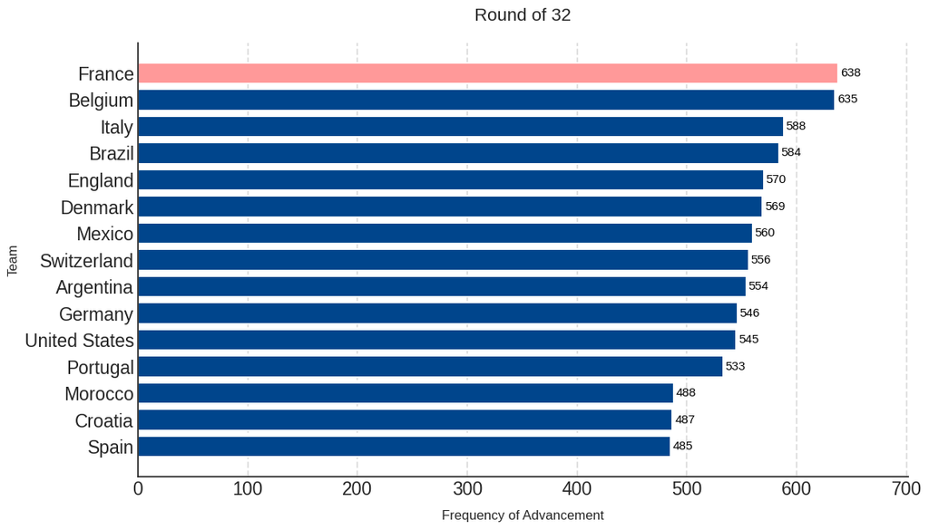

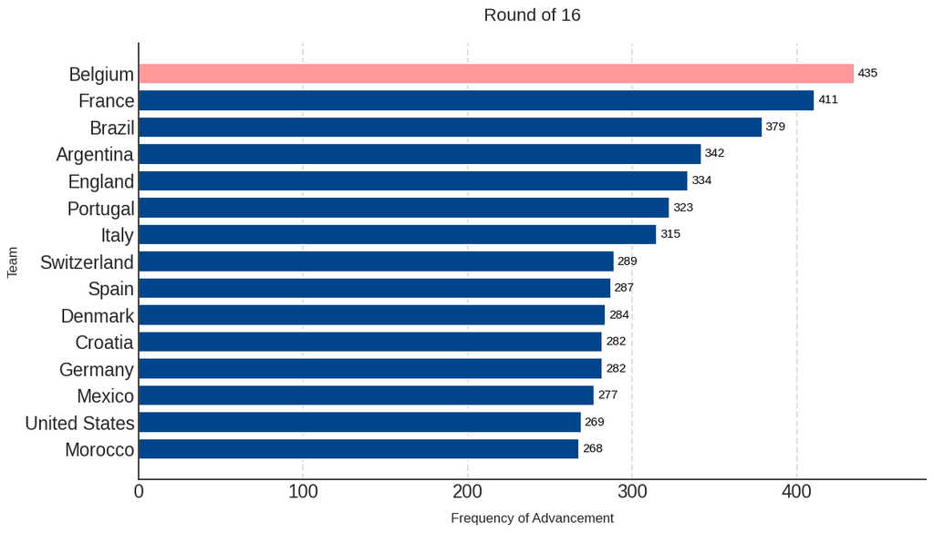

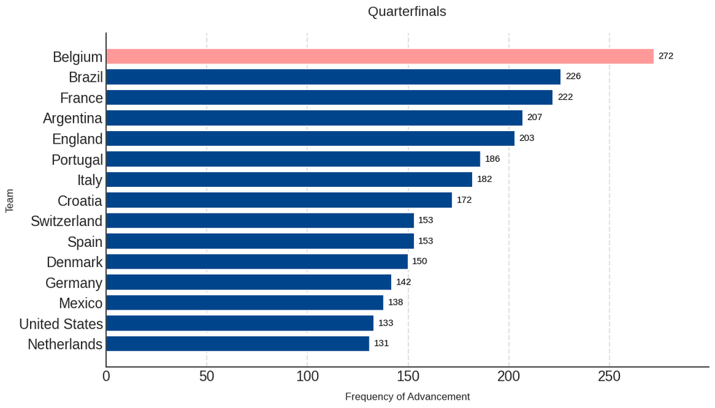

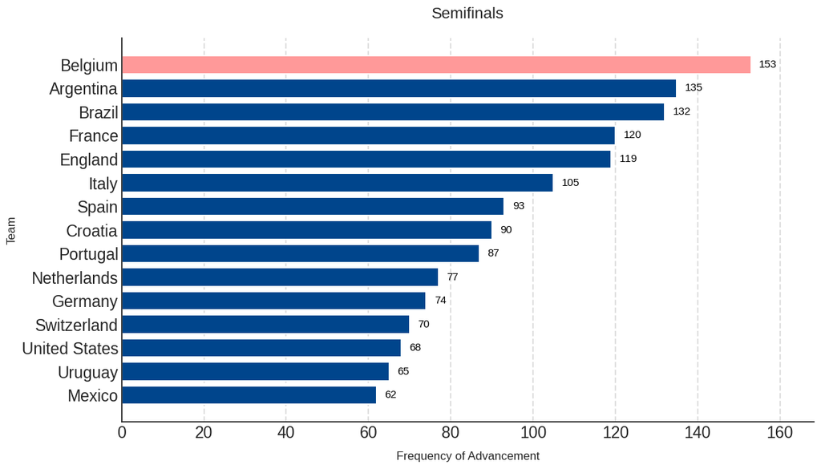

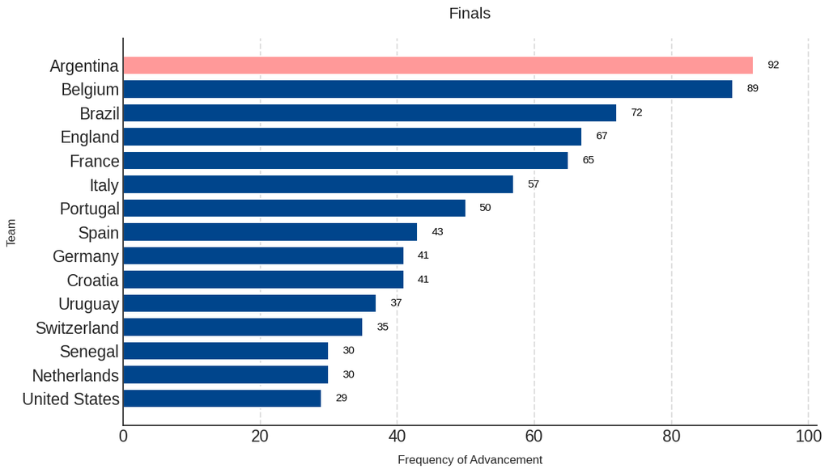

```python
# Visualize simulation
WINNER_COLOR = '#ff9999'
STANDARD_COLOR = '#00458C'

for i in results_real:
    results = Counter(i).most_common(15)
    x, y = zip(*results)

    if i == results_round_of_32:
        title_name = "Round of 32"
    elif i == results_round_of_16:
        title_name = "Round of 16"
    elif i == results_quarterfinals:
        title_name = "Quarterfinals"
    elif i == results_semifinals:
        title_name = "Semifinals"
    elif i == results_finals:
        title_name = "Finals"
    else:
        continue

    num_bars = len(x)
    colors = [STANDARD_COLOR] * num_bars
    if num_bars > 0:
        colors[0] = WINNER_COLOR

    plt.style.use('seaborn-v0_8-white')
    fig, ax = plt.subplots(figsize=(12, 7))
    bars = ax.barh(x, y, color=colors)

    for bar in bars:
        width = bar.get_width()
        y_pos = bar.get_y() + bar.get_height() / 2
        label_color = 'black' if bar.get_facecolor()[0] != 0.0 else 'black'
        ax.text(width + 2, y_pos, f'{width}', ha='left', va='center', fontsize=11, color=label_color)

    # Set Title and Labels
    ax.set_title(title_name, fontsize=16, pad=20)
    ax.set_xlabel("Frequency of Advancement", fontsize=12, labelpad=10)
    ax.set_ylabel("Team", fontsize=12)

    # Reverse Y-axis and clean up
    ax.invert_yaxis()
    ax.spines['right'].set_visible(False)
    ax.spines['top'].set_visible(False)
    ax.grid(axis='x', linestyle='--', alpha=0.6)
    ax.set_xlim(right=max(y) * 1.1)

    fig.tight_layout()
    plt.show()
```

```
AUC Score: 0.7680
```

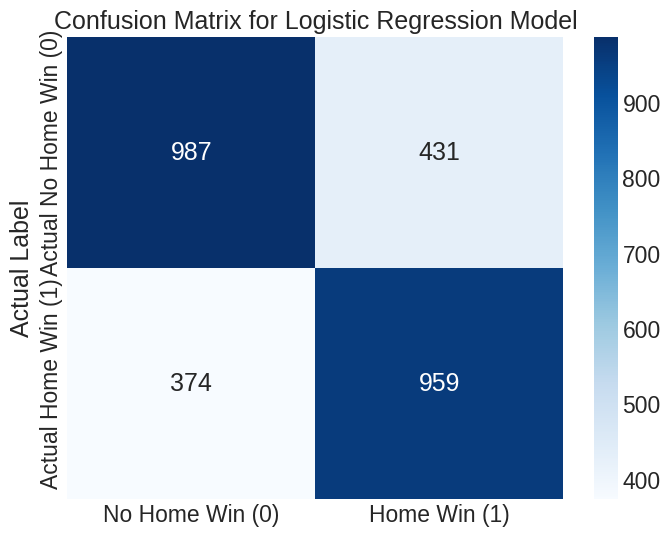

```
Accuracy: 0.71
Precision: 0.69
Recall: 0.72
F1 Score: 0.70
```

```python
# Generate Class Predictions on the Test Set
y_pred = model.predict(X_test)
y_proba_pred = model.predict_proba(X_test)[:, 1]

auc_score = roc_auc_score(y_test, y_proba_pred)
print(f"AUC Score: {auc_score:.4f}")

# Calculate the Confusion Matrix
conf_matrix = confusion_matrix(y_test, y_pred)
accuracy = accuracy_score(y_test, y_pred)
precision = precision_score(y_test, y_pred)
recall = recall_score(y_test, y_pred)
f1 = f1_score(y_test, y_pred)

# Visual where rows are the actual classes (y_test), columns are the predicted classes (y_pred).
plt.figure(figsize=(8, 6))
sns.heatmap(conf_matrix, annot=True, fmt='d', cmap='Blues',
            xticklabels=['No Home Win (0)', 'Home Win (1)'],
            yticklabels=['Actual No Home Win (0)', 'Actual Home Win (1)'])
plt.title('Confusion Matrix for Logistic Regression Model')
plt.ylabel('Actual Label')
plt.show()

print(f"Accuracy: {accuracy:.2f}")
print(f"Precision: {precision:.2f}")
print(f"Recall: {recall:.2f}")
print(f"F1 Score: {f1:.2f}")
# Interpretation
# [0, 0]: True Negatives (Correctly predicted no Home Win)
# [0, 1]: False Positives (Incorrectly predicted Home Win)
# [1, 0]: False Negatives (Incorrectly predicted no Home Win)
# [1, 1]: True Positives (Correctly predicted Home Win)
```

- Accuracy = 0.71, correctly predicting 71% of match outcomes.
- Precision = 0.69, when the model predicts a home win, the prediction is correct 69% of the time.
- Recall = 0.72, the model is able to capture approximately 72% of actual home team wins.
- F1 = 0.7, indicating a balanced performance between precision and recall in predicting home wins.

# **Trying RandomForest and XGBoost**

```
XGBoost AUC Score: 0.7706
```

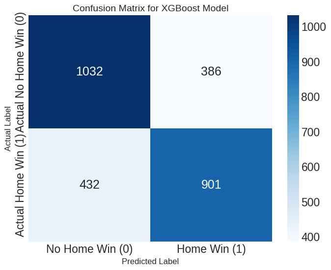

```
--- XGBoost Classification Metrics ---
Accuracy: 0.7027
Precision: 0.7001
Recall: 0.6759
F1 Score: 0.6878
```

```python
xgb_model = XGBClassifier(
    n_estimators=100,
    learning_rate=0.1,
    use_label_encoder=False,
    eval_metric='logloss',
    random_state=42
)
xgb_model.fit(X_train, y_train)

y_proba_xgb = xgb_model.predict_proba(X_test)[:, 1]
y_pred_xgb = xgb_model.predict(X_test)

# Calculate AUC Score
xgb_auc = roc_auc_score(y_test, y_proba_xgb)
print(f"XGBoost AUC Score: {xgb_auc:.4f}")

# Calculate the Confusion Matrix and Metrics
conf_matrix = confusion_matrix(y_test, y_pred_xgb)
accuracy = accuracy_score(y_test, y_pred_xgb)
precision = precision_score(y_test, y_pred_xgb)
recall = recall_score(y_test, y_pred_xgb)
f1 = f1_score(y_test, y_pred_xgb)

# Visual where rows are the actual classes (y_test), columns are the predicted classes (y_pred).
plt.figure(figsize=(8, 6))
sns.heatmap(conf_matrix, annot=True, fmt='d', cmap='Blues',
            xticklabels=['No Home Win (0)', 'Home Win (1)'],
            yticklabels=['Actual No Home Win (0)', 'Actual Home Win (1)'])
plt.title('Confusion Matrix for XGBoost Model', fontsize=14)
plt.ylabel('Actual Label', fontsize=12)
plt.xlabel('Predicted Label', fontsize=12)
plt.savefig('xgboost_confusion_matrix.png')
plt.show()

print("--- XGBoost Classification Metrics ---")
print(f"Accuracy: {accuracy:.4f}")
print(f"Precision: {precision:.4f}")
print(f"Recall: {recall:.4f}")
print(f"F1 Score: {f1:.4f}")
```

```
Random Forest AUC Score: 0.7700
```

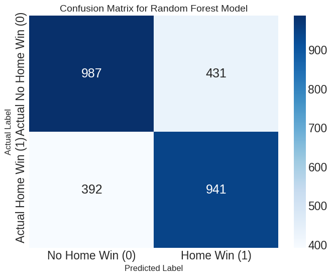

```
--- Random Forest Classification Metrics ---
Accuracy: 0.7008
Precision: 0.6859
Recall: 0.7059
F1 Score: 0.6957
```

```python
rf_model = RandomForestClassifier(
    n_estimators=100,
    max_depth=10,
    random_state=42,
    class_weight='balanced'
)
rf_model.fit(X_train, y_train)
y_proba_rf = rf_model.predict_proba(X_test)[:, 1]
y_pred_rf = rf_model.predict(X_test)

# Calculate AUC
rf_auc = roc_auc_score(y_test, y_proba_rf)
print(f"Random Forest AUC Score: {rf_auc:.4f}")

# Calculate the Confusion Matrix and Metrics (using hard predictions)
conf_matrix = confusion_matrix(y_test, y_pred_rf)
accuracy = accuracy_score(y_test, y_pred_rf)
precision = precision_score(y_test, y_pred_rf)
recall = recall_score(y_test, y_pred_rf)
f1 = f1_score(y_test, y_pred_rf)

# Visual where rows are the actual classes (y_test), columns are the predicted classes (y_pred).
plt.figure(figsize=(8, 6))
sns.heatmap(conf_matrix, annot=True, fmt='d', cmap='Blues',
            xticklabels=['No Home Win (0)', 'Home Win (1)'],
            yticklabels=['Actual No Home Win (0)', 'Actual Home Win (1)'])
plt.title('Confusion Matrix for Random Forest Model', fontsize=14)
plt.ylabel('Actual Label', fontsize=12)
plt.xlabel('Predicted Label', fontsize=12)
plt.savefig('random_forest_confusion_matrix.png')
plt.show()

print("--- Random Forest Classification Metrics ---")
print(f"Accuracy: {accuracy:.4f}")
print(f"Precision: {precision:.4f}")
print(f"Recall: {recall:.4f}")
print(f"F1 Score: {f1:.4f}")
```

# **Further Feature Engineering**

Since our logistic regression model is stable but has hit a performance ceiling, a potential way to increase performance is to introduce new features that contain predictive information not found in the FIFA ranking.

The next feature to implement is the team form feature, which measures a team's recent momentum. We calculate team momentum by assigning each team a score from 0-1 that represents their performance every 10 historical games. Where:

- 1.0 - Won the last 10 games
- 0.5 - Equal wins/loses
- 0.0 - Lost the last 10 games

Then we calculated the rolling means of the last 10 results for each country, next we normalized the output so it gives us 0-1 values by applying the formula (rolling means + 1)/2, giving us home_form and away_form allowing us to calculate form/momentum difference.

We proceeded with implementing the team form feature engineering step. After doing so, we re-run the AUC plot to see if there's an improvement in performance.

To learn more about how we calcualted team momentum visit this [link](https://www.sportmonks.com/glossary/team-form-analytics/#:~:text=Rolling%20averages%20and%20moving%20windows,of%20metrics%20like%20xG%20difference.)

```python
# Determines result (1=Win, 0=Draw, -1=Loss) based on scores.
def get_team_result(row):
    if row['score'] > row['opponent_score']:
        return 1
    if row['score'] < row['opponent_score']:
        return -1
    return 0

# Calculates the rolling form (Win Rate).
def calculate_form(df, team_col, n_matches=10):
    # Apply get_team_result function
    df['team_result'] = df.apply(get_team_result, axis=1)

    # Calculate rolling average of results (momentum)
    df[f'{team_col}_form'] = (
        df.groupby(team_col)['team_result']
        .rolling(window=n_matches, min_periods=1)
        .mean()
        .shift(1) # shift by 1
        .reset_index(level=0, drop=True)
    )

    # Normalize from (-1,1) -> (0,1)
    df[f'{team_col}_form'] = (df[f'{team_col}_form'] + 1) / 2

    df.drop(columns=['team_result'], inplace=True)
    return df
```

```python
# Copy original historical dataset
df_form = df.copy()

home_df = df_form[['date', 'home_team', 'home_score', 'away_score']].rename(
    columns={'home_team': 'team', 'away_team': 'opponent', 'home_score': 'score', 'away_score': 'opponent_score'}
)
away_df = df_form[['date', 'away_team', 'away_score', 'home_score']].rename(
    columns={'away_team': 'team', 'home_team': 'opponent', 'away_score': 'score', 'home_score': 'opponent_score'}
)

# Combine and sort by team and date to make sure the rolling means calculation is sequential/chronological
combined_df = pd.concat([home_df, away_df]).sort_values(by=['team', 'date'])

# Calculate the form on the combined historical data
combined_df = calculate_form(combined_df, 'team', n_matches=10)
```

```python
# Merge the form features for both teams in df_2026
df_2026 = pd.merge(df_2026,
              combined_df[['date', 'team', 'team_form']],
              left_on=['date', 'home_team'],
              right_on=['date', 'team'],
              how='left',
              suffixes=('', '_home_temp'))
df_2026.rename(columns={'team_form': 'home_form'}, inplace=True)

df_2026 = pd.merge(df_2026,
              combined_df[['date', 'team', 'team_form']],
              left_on=['date', 'away_team'],
              right_on=['date', 'team'],
              how='left',
              suffixes=('', '_away_temp'))
df_2026.rename(columns={'team_form': 'away_form'}, inplace=True)


# Fill null rows with a neutral win rate of 0.5
df_2026['home_form'].fillna(0.5, inplace=True)
df_2026['away_form'].fillna(0.5, inplace=True)

# Create form difference feature
df_2026['form_diff'] = df_2026['home_form'] - df_2026['away_form']
df_2026.drop(columns=['team_away_temp'], inplace=True)
```

Now after succesfully performing feature engineering we plot our ROC Curve and compare performance with our initial model

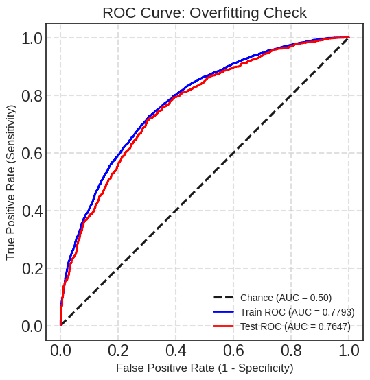

```python
# train the model with form_diff
X, y = df_2026.loc[:,["rank_diff", "fifa_points_diff", "form_diff"]], df_2026["home_won"]
X_train, X_test, y_train, y_test = train_test_split(X, y, test_size=0.2, random_state=42)

logreg = linear_model.LogisticRegression(random_state=42, max_iter=100)
model = logreg.fit(X_train, y_train)

features = PolynomialFeatures(degree = 2)
model = Pipeline([("polynomial_features", features),("logistic_regression", logreg)])
model = model.fit(X_train, y_train)

y_proba_test = model.predict_proba(X_test)[:, 1]
fpr_test, tpr_test, _ = roc_curve(y_test, y_proba_test)
auc_test = roc_auc_score(y_test, y_proba_test)

y_proba_train = model.predict_proba(X_train)[:, 1]
fpr_train, tpr_train, _ = roc_curve(y_train, y_proba_train)
auc_train = roc_auc_score(y_train, y_proba_train)

plt.figure(figsize=(6, 6), dpi=100)
ax = plt.gca()
ax.plot([0, 1], [0, 1], 'k--', label='Chance (AUC = 0.50)')

# Plot Training ROC Curve
ax.plot(fpr_train, tpr_train,
        label=f'Train ROC (AUC = {auc_train:.4f})',
        color='blue', linewidth=2)

# Plot Test ROC Curve
ax.plot(fpr_test, tpr_test,
        label=f'Test ROC (AUC = {auc_test:.4f})',
        color='red', linewidth=2)

# Set labels and title
ax.set_title('ROC Curve: Overfitting Check', fontsize=16)
ax.set_xlabel('False Positive Rate (1 - Specificity)', fontsize=12)
ax.set_ylabel('True Positive Rate (Sensitivity)', fontsize=12)

# Add Legend and ensure square aspect ratio
ax.legend(loc="lower right", fontsize=10)
ax.set_aspect('equal', adjustable='box')
ax.grid(True, linestyle='--', alpha=0.6)

plt.show()
```

After plotting our new ROC plot, we see not major improvements in performance with our new feature. This means that our initial model has reached it's performance ceiling considering all the other options we have tried for improvement. Since the more complex models like XGBoost and RandomForest provided no significant boost in our prediction, our Logisitic Regression model is the most robust, efficient and stable model for our FIFA World Cup predictions given the data and features.

# **Final Thoughts**

Predicting the World Cup winner with high accuracy is very complicated due to it's inherent nature in randomness and it's complexity in quantifying intangible factors like experience, motivation, home advantage, etc. Making it very hard to solve it in a single tutorial. However, we were able to build a robust model yielded good performance.

This tutorial can be very useful for an uninformed reader as it guides the reader step by step from the purpose of building a World Cup match prediction to the step-by-step explanation of data collection, data processing, evaluation and modelling/simulation ensuring readers with no prior knowledge can understand the the analysis. Furthermore, a knowledgeable reader would still gain valuable information, particularly, with the integration of logistic regression with Monte Carlo simulation as a powerful tool for predicting world cup match outcomes.

# **Related Link**

If you want to do more with data science, or the problem of predicting the World Cup Winner, please see the following links:

### Statistical Analysis

- [T-Test](https://docs.scipy.org/doc/scipy/reference/generated/scipy.stats.ttest_ind.html)
- [Pearsonr](https://docs.scipy.org/doc/scipy/reference/generated/scipy.stats.pearsonr.html)

### Machine Learning

- [Logistic Regression](https://github.com/learn-co-curriculum/dsc-logistic-regression-lab)
- [Polynomial Features](https://scikit-learn.org/stable/modules/generated/sklearn.preprocessing.PolynomialFeatures.html)